## 1533: Data Mining and Decision Support Systems

# Session 3 Homework

Authors: Alexander Neulinger - 1025792, Michael Graf - 1152091, Filip Minic - 1053044

```python
import random
import numpy as np
import pandas as pd
% matplotlib inline
import matplotlib.pyplot as plt
from sklearn.metrics import accuracy_score
from sklearn.model_selection import KFold, train_test_split, cross_val_predict, cross_val_score
from sklearn.preprocessing import *
from lightning.regression import AdaGradRegressor
from sklearn.naive_bayes import GaussianNB
from sklearn.discriminant_analysis import *
from sklearn.neighbors import KNeighborsClassifier
from sklearn.linear_model import *
import warnings

warnings.filterwarnings("ignore")
% matplotlib inline
```

# Exercise 1

Use the SGDClassifier provided by scikit-learn. Set loss='log', learning_rate='constant', alpha=0.0, random_state=191. Set n_iter=10, so that the SGDClassifier will sweep the sample 10 times. The stepsize is defined by the parameter eta0. Use 5-fold cross validation to search for a good eta0.

```python
df = pd.read_csv('https://web.stanford.edu/~hastie/ElemStatLearn/datasets/spam.data',
                 engine='python', sep='\\s', header=None)
feat_index = list(range(57))
df.columns = feat_index + ['Spam']
df.head()
```

|  | 0 | 1 | 2 | 3 | 4 | 5 | 6 | 7 | 8 | 9 | ... | 48 | 49 | 50 | 51 | 52 | 53 | 54 | 55 | 56 | Spam |
| --- | --- | --- | --- | --- | --- | --- | --- | --- | --- | --- | --- | --- | --- | --- | --- | --- | --- | --- | --- | --- | --- |
| 0 | 0.00 | 0.64 | 0.64 | 0.0 | 0.32 | 0.00 | 0.00 | 0.00 | 0.00 | 0.00 | ... | 0.00 | 0.000 | 0.0 | 0.778 | 0.000 | 0.000 | 3.756 | 61 | 278 | 1 |
| 1 | 0.21 | 0.28 | 0.50 | 0.0 | 0.14 | 0.28 | 0.21 | 0.07 | 0.00 | 0.94 | ... | 0.00 | 0.132 | 0.0 | 0.372 | 0.180 | 0.048 | 5.114 | 101 | 1028 | 1 |
| 2 | 0.06 | 0.00 | 0.71 | 0.0 | 1.23 | 0.19 | 0.19 | 0.12 | 0.64 | 0.25 | ... | 0.01 | 0.143 | 0.0 | 0.276 | 0.184 | 0.010 | 9.821 | 485 | 2259 | 1 |
| 3 | 0.00 | 0.00 | 0.00 | 0.0 | 0.63 | 0.00 | 0.31 | 0.63 | 0.31 | 0.63 | ... | 0.00 | 0.137 | 0.0 | 0.137 | 0.000 | 0.000 | 3.537 | 40 | 191 | 1 |
| 4 | 0.00 | 0.00 | 0.00 | 0.0 | 0.63 | 0.00 | 0.31 | 0.63 | 0.31 | 0.63 | ... | 0.00 | 0.135 | 0.0 | 0.135 | 0.000 | 0.000 | 3.537 | 40 | 191 | 1 |

5 rows × 58 columns

```python
x = df[feat_index].values
y = df.Spam.values
cross_val_score
x_train, x_test, y_train, y_test = train_test_split(x, y, test_size=0.25)
```

Since we have to use 5-fold cross validation we wil calculate our cross validation by dividing our sample into 5 different groups.

```python
clf = LogisticRegression()
clf.fit(x_train, y_train)
prediction = cross_val_predict(clf, x, y, cv=5)
minscore = min(cross_val_score(clf, x, y, cv=5, n_jobs=1))
clf = SGDClassifier(alpha=0.0, loss='log', learning_rate='constant', random_state=191, max_iter=10, eta0=minscore)
clf.fit(x_train, y_train)
accuracy = clf.score(x_test, y_test)
print("The accuracy is: %.2f%%" % (100 * accuracy))
```

```
The accuracy is: 77.50%
```

```python
clf = SGDClassifier(loss='log', learning_rate='constant', eta0=0.01, alpha=0.0, max_iter=10)
clf.fit(x_train, y_train)
accuracy = clf.score(x_test, y_test)
print("The accuracy is: %.2f%%" % (100 * accuracy))
```

```
The accuracy is: 79.93%
```

## Exercise 2

Implement a variant of logistic regression using stochastic gradient ascent with AdaGrad stepsizes. Make sure that the sample size is 10 times the training set size, so that your classifier sees as many data points as the SGDClassifier.

```python
class AdaGradSGA:
    def __init__(self, X, y):
        self.X = X
        self.y = y
        self.n = 10 * len(X)
        self.b = None

    def adaGrad(self)-> None:
        X = self.X
        y = self.y
        n = self.n
        g0 = np.ones(len(X[0]))
        b = np.zeros(len(X[0]))
        n = len(y)
        for j in range(n):
            i = random.randint(0, len(x) - 1)
            grad = (y[i] - (1 + (np.exp(-b.dot(x[i])) ** -1))) * x[i]
            g0 += grad ** 2
            b = b + grad / np.sqrt(g0)
        self.b = b
        return b

    def score(self):
        b = self.b
        x = self.X
        y = self.y
        predictedY = y.copy()
        for i in range(len(y) - 1):
            predictedY[i] = 1. / (1 + (np.exp(-b.dot(x[i]))))
        accuracy = accuracy_score(y, predictedY)
        return accuracy
```

```python
scaler = StandardScaler().fit(x)
x_scaled = scaler.transform(x)
log_model = AdaGradSGA(x_scaled, y)
log_model.adaGrad()
print("The accuracy of the model is %.2f%%" % (log_model.score()*100))
```

```
The accuracy of the model is 37.62%
```

## Exercise 3

Compare your own classifier against SGDClassifier, LogisticRegression, and the optimal KNeighborsClassifier using the function accuracy_dist(). Note that, for this you should implement your own in its own class which must implement the functions fit(X,y) and score(X,y). The trick is to use a class variable for the parameters, e.g., self.beta, which can be accessed in both functions. If creating a class seems to difficult a function that does both, fitting and scoring, will also do the trick.

```python
def accuracy_dist(clfs, X, y, n=10):
    accuracy = np.zeros((n, len(clfs)))
    columns = [clf.__class__.__name__ for clf in clfs]
    for i in range(n):
        X_train, X_test, y_train, y_test = train_test_split(X, y, random_state=31 * i)
        for j in range(len(clfs)):
            clf = clfs[j]
            clf.fit(X_train, y_train)
            accuracy[i][j] = clf.score(X_test, y_test)
    return pd.DataFrame(accuracy, columns=columns, index=range(n))
```

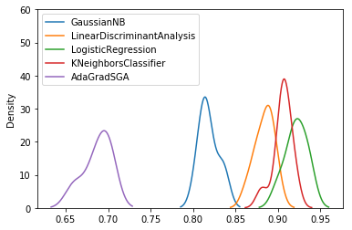

```python
accuracy_df = accuracy_dist([GaussianNB(), LinearDiscriminantAnalysis(), LogisticRegression()], x, y)
accuracy_df = pd.concat(
    (accuracy_df, accuracy_dist([KNeighborsClassifier(), AdaGradSGA()], StandardScaler().fit_transform(x), y)), axis=1)
accuracy_df.plot(kind='kde', ylim=[0, 60])
plt.show()
```

## Exercise 4

Use 5-fold cross validation to search for the optimal n_neighbors of the KNeighborsClassifier.

```
The optimal number of neighbors is 4 with 77.7391304348
```

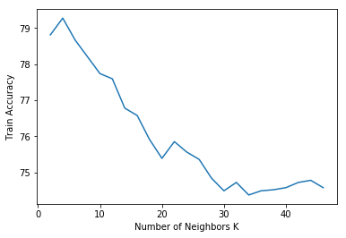

```python
neighbours = [i for i in range(2, 48, 2)]

cv_scores = []

for k in neighbours:
    k_classifier = KNeighborsClassifier(n_neighbors=k,
                               weights='uniform',
                               p=2,
                               metric='euclidean')
    kfold = KFold(n_splits=5)
    scores = cross_val_score(k_classifier,
                             x_train,
                             y_train,
                             cv=kfold,
                             scoring='accuracy')
    cv_scores.append(scores.mean() * 100)

optimal_k = neighbours[cv_scores.index(max(cv_scores))]

print("The optimal number of neighbors is "
      + str(optimal_k)
      + " with "
      + str(cv_scores[optimal_k]))

plt.plot(neighbours, cv_scores)
plt.xlabel('Number of Neighbors K')
plt.ylabel('Train Accuracy')
plt.show()
```